# Storm Data Analysis to Identify the Most Damaging Disaster Types to Population Health and Economy

Angela Liu

September 17, 2018

# 1 Synopsis

Severe weather often lead to natural disaters that could adversely affect human beings by killing or injuring people and damaging their properties or crops. In this report, the U.S. National Oceanic and Atmospheric Administration’s (NOAA) storm data set is analyzed to identify the weather event types that result in the most severe damages. We use fatality rate, injury, property damage, and crop damage as the main metrics to assess the damage of each weather event type to people and to the economy. We found that tornado, heat, and flood are the top three disaster types incurring the most damage to people, based on the fatality and injury data. In comparison, tornado, flood, and wind are found to be the top three disaster types causing the most economical loss due to property and crop damage. Limitations of this work and future studies are also outlined.

# 2 Data Processing

The U.S. National Oceanic and Atmospheric Administration’s (NOAA) storm data set is downloaded from “https://d396qusza40orc.cloudfront.net/repdata%2Fdata%2FStormData.csv.bz2” onto the local hard drive. Then the file is read in by R into a data frame for analysis.

```r
require(grDevices)
```

```r
# download bz2 file to local folder
weblink <- "https://d396qusza40orc.cloudfront.net/repdata%2Fdata%2FStormData.csv.bz2"
destfile <- "storm_data.csv.bz2"
success_code <- 0

# if file has not been downloaded, download it to local folder
if(!file.exists(destfile)){
  success_code <- download.file(weblink, destfile)
}

# if file has been successfully downloaded, read it into a data frame
if (success_code == 0) {
  data <- read.csv(destfile, header=TRUE, sep=",", quote="\"")
}

# visually inspect the data frame structure and first a few rows
str(data)
```

```
## 'data.frame':    902297 obs. of  37 variables:
##  $ STATE__   : num  1 1 1 1 1 1 1 1 1 1 ...
##  $ BGN_DATE  : Factor w/ 16335 levels "1/1/1966 0:00:00",..: 6523 6523 4242 11116 2224 2224 2260 383 3980 3980 ...
##  $ BGN_TIME  : Factor w/ 3608 levels "00:00:00 AM",..: 272 287 2705 1683 2584 3186 242 1683 3186 3186 ...
##  $ TIME_ZONE : Factor w/ 22 levels "ADT","AKS","AST",..: 7 7 7 7 7 7 7 7 7 7 ...
##  $ COUNTY    : num  97 3 57 89 43 77 9 123 125 57 ...
##  $ COUNTYNAME: Factor w/ 29601 levels "","5NM E OF MACKINAC BRIDGE TO PRESQUE ISLE LT MI",..: 13513 1873 4598 10592 4372 10094 1973 23873 24418 4598 ...
##  $ STATE     : Factor w/ 72 levels "AK","AL","AM",..: 2 2 2 2 2 2 2 2 2 2 ...
##  $ EVTYPE    : Factor w/ 985 levels "   HIGH SURF ADVISORY",..: 834 834 834 834 834 834 834 834 834 834 ...
##  $ BGN_RANGE : num  0 0 0 0 0 0 0 0 0 0 ...
##  $ BGN_AZI   : Factor w/ 35 levels "","  N"," NW",..: 1 1 1 1 1 1 1 1 1 1 ...
##  $ BGN_LOCATI: Factor w/ 54429 levels "","- 1 N Albion",..: 1 1 1 1 1 1 1 1 1 1 ...
##  $ END_DATE  : Factor w/ 6663 levels "","1/1/1993 0:00:00",..: 1 1 1 1 1 1 1 1 1 1 ...
##  $ END_TIME  : Factor w/ 3647 levels ""," 0900CST",..: 1 1 1 1 1 1 1 1 1 1 ...
##  $ COUNTY_END: num  0 0 0 0 0 0 0 0 0 0 ...
```

[output cut: 23 more lines]

```r
head(data)
```

```
##   STATE__           BGN_DATE BGN_TIME TIME_ZONE COUNTY COUNTYNAME STATE
## 1       1  4/18/1950 0:00:00     0130       CST     97     MOBILE    AL
## 2       1  4/18/1950 0:00:00     0145       CST      3    BALDWIN    AL
## 3       1  2/20/1951 0:00:00     1600       CST     57    FAYETTE    AL
## 4       1   6/8/1951 0:00:00     0900       CST     89    MADISON    AL
## 5       1 11/15/1951 0:00:00     1500       CST     43    CULLMAN    AL
## 6       1 11/15/1951 0:00:00     2000       CST     77 LAUDERDALE    AL
##    EVTYPE BGN_RANGE BGN_AZI BGN_LOCATI END_DATE END_TIME COUNTY_END
## 1 TORNADO         0                                               0
## 2 TORNADO         0                                               0
## 3 TORNADO         0                                               0
## 4 TORNADO         0                                               0
## 5 TORNADO         0                                               0
## 6 TORNADO         0                                               0
##   COUNTYENDN END_RANGE END_AZI END_LOCATI LENGTH WIDTH F MAG FATALITIES
```

[output cut: 20 more lines]

# 3 Results

## 3.1 Events Most Harmful to Population Health

In the first part of the analysis, we aim to find what disaster events are the most harmful to population health. We examine the storm data and focus on the fatality and injury counts. We first find all unique disaster event types by converting event types into all uppercase representation. Then for each diaster event type, we find the total count of the number of fatalities or injuries. We then sort the counts in descending order to find the disaster event types causing the most harm to human health. We sort first using the fatality counts and then using the injury counts. A bar plot showing the top 20 event types summarizes this finding graphically.

```r
# extract event type, fatality, and injury data to form a new data frame
health_data <- cbind.data.frame("EVTYPE"=data$EVTYPE, "FATAL"=data$FATALITIES, "INJUR"=data$INJURIES)

# find unique (formatted to be uppercase) event types
ev_types <- unique(toupper(health_data$EVTYPE))

# form a new data frame using the unique event types
dam_count <- matrix(0, ncol=2, nrow=length(ev_types))

# for each event type, sum up the fatality and injury counts across multiple events
for (index in 1:length(ev_types)) {
  evtype <- ev_types[index]
  dam_count[index, 1] <-  sum(health_data$FATAL[health_data$EVTYPE==evtype])
  dam_count[index, 2] <-  sum(health_data$INJUR[health_data$EVTYPE==evtype])
}

# form a data frame to contain the event type and damage count data (both fatality and injury)
dam_data <- cbind.data.frame("EVTYPE"=ev_types, "FATCNT"=dam_count[, 1], "INJCNT"=dam_count[, 2])

# sort dam_data in descending order according to fatality first and then according to injuries
dam_sorted <- dam_data[order(-dam_data$FATCNT, -dam_data$INJCNT), ]

# print out the first 20 event types with the most damage to health, i.e.,
#     with the highest fatality rate and injury counts
head(dam_sorted, n=20)
```

```
##                      EVTYPE FATCNT INJCNT
## 1                   TORNADO   5633  91346
## 99           EXCESSIVE HEAT   1903   6525
## 20              FLASH FLOOD    978   1777
## 27                     HEAT    937   2100
## 15                LIGHTNING    816   5230
## 2                 TSTM WIND    504   6957
## 36                    FLOOD    470   6789
## 18              RIP CURRENT    368    232
## 46                HIGH WIND    248   1137
## 73                AVALANCHE    224    170
## 8              WINTER STORM    206   1321
## 443            RIP CURRENTS    204    297
## 182               HEAT WAVE    172    309
## 43             EXTREME COLD    160    231
## 16        THUNDERSTORM WIND    133   1488
## 53               HEAVY SNOW    127   1021
## 880 EXTREME COLD/WIND CHILL    125     24
## 137             STRONG WIND    103    280
## 47                 BLIZZARD    101    805
## 111               HIGH SURF    101    152
```

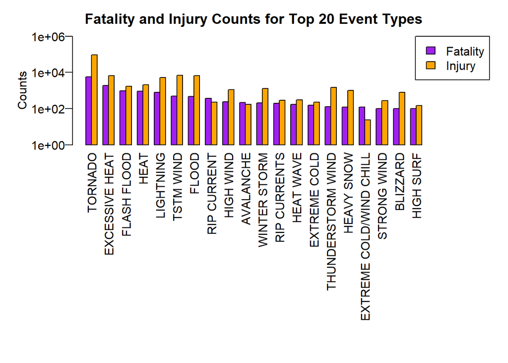

Figure 3.1: Top 20 weather event types with the most damage to population health.

```r
# use the top 20 data for plotting
top_dam_data <- dam_sorted[1:20, ]

# plot the sorted damage counts using a barplot for the top 20 diaster types
par(mai=c(3,1,0.5,1), mgp=c(3,0.5,0), xpd=TRUE)
barplot(rbind(top_dam_data$FATCNT, top_dam_data$INJCNT), beside=TRUE, names.arg=top_dam_data$EVTYPE,
main="Fatality and Injury Counts for Top 20 Event Types", col=cbind("purple", "orange"), ylab="Counts", ylim=c(1,1000000), log='y', las=2)
legend("topright", legend=c("Fatality", "Injury"), inset=c(-0.15, 0), fill=cbind("purple", "orange"))
```

From Figure 3.1, we can see that tornado, excessive heat, and flash flood are the three top adverse weather types that cause the most harm to population health (fatality and injury).

## 3.2 Events Most Damaging to Economy

For the second part of the analysis, we examine the damage to property and crops caused by each adverse weather event. We first transform all dollar values of the property damage and crop damage to the same unit in dollars. We then conduct a similar analysis to the first part where we find the total amount of damage caused by each event type. The final ranked results of total property and crop damage will be shown in a table and a bar plot.

```r
# extract propery damage values and crop damage values
prop_data <- cbind.data.frame("EVTYPE"=data$EVTYPE, "PROPDMG"=data$PROPDMG)
crop_data <- cbind.data.frame("EVTYPE"=data$EVTYPE, "CROPDMG"=data$CROPDMG)

# number of rows in data
nrows <- dim(data)[1]

# a function to convert damage value into real dollar value by multiplying the dimension scale
find_scale_factors <- function(original_data, nrows) {
  # initialize to all zeros in a vector
  scale_factors <- matrix(0, nrow=length(original_data))

  # for each property or crop damage value, convert it into its real number value
  # based on:
  # https://rstudio-pubs-static.s3.amazonaws.com/58957_37b6723ee52b455990e149edde45e5b6.html
  #     only factors h, H, k, K, m, M, b, and B are considered.
  #     Other factors are ignored and those rows are treated as zero and will be ranked
  #     at the bottom in sorting.
  for (irow in 1:nrows) {
    if (original_data[irow] == "H" || original_data[irow] == "h") {
      scale_factors <- 1E+2
    } else if (original_data[irow] == "K" || original_data[irow] == "k") {
      scale_factors <- 1E+3
    } else if (original_data[irow] == "M" || original_data[irow] == "m") {
      scale_factors <- 1E+6
    } else if (original_data[irow] == "B" || original_data[irow] == "b") {
      scale_factors <- 1E+9
    }
  }
  return(scale_factors)
}

# property and crop damage scale factors
prop_dimen_scale <- find_scale_factors(data$PROPDMGEXP, nrows)
crop_dimen_scale <- find_scale_factors(data$CROPDMGEXP, nrows)

# update the property and crop damage data frame by the dimension scaling factor
prop_data$PROPDMG <- prop_data$PROPDMG * prop_dimen_scale
crop_data$CROPDMG <- crop_data$CROPDMG * crop_dimen_scale

# form a new data frame to store the damage dollar amount using the unique event types
dam_amount <- matrix(0, nrow=length(ev_types))

# for each event type, sum up the property and crop damage dollar amount across multiple events
for (index in 1:length(ev_types)) {
  evtype <- ev_types[index]
  dam_amount[index] <-  sum(prop_data$PROPDMG[prop_data$EVTYPE==evtype]) + sum(crop_data$CROPDMG[crop_data$EVTYPE==evtype])
}

# form a data frame to contain the event type and damage dollar totals
eco_data <- cbind.data.frame("EVTYPE"=ev_types, "DMG"=dam_amount)

# total damage sorted in descending order of dollar amount
eco_data_sorted <- eco_data[order(-eco_data$DMG), ]
```

```r
# print out the top 20 events with total damage (property + crop)
head(eco_data_sorted, n=20)
```

```
##                 EVTYPE        DMG
## 1              TORNADO 3312276680
## 20         FLASH FLOOD 1599325050
## 2            TSTM WIND 1445168210
## 3                 HAIL 1268289660
## 36               FLOOD 1067976360
## 16   THUNDERSTORM WIND  943635620
## 15           LIGHTNING  606932390
## 10  THUNDERSTORM WINDS  464978110
## 46           HIGH WIND  342014770
## 8         WINTER STORM  134699580
## 53          HEAVY SNOW  124417710
## 221           WILDFIRE   88823540
## 65           ICE STORM   67689620
## 137        STRONG WIND   64610710
## 14          HEAVY RAIN   61964940
## 22          HIGH WINDS   57384600
## 209     TROPICAL STORM   54322800
## 227   WILD/FOREST FIRE   43534490
## 194            DROUGHT   37997670
## 21      FLASH FLOODING   33623200
```

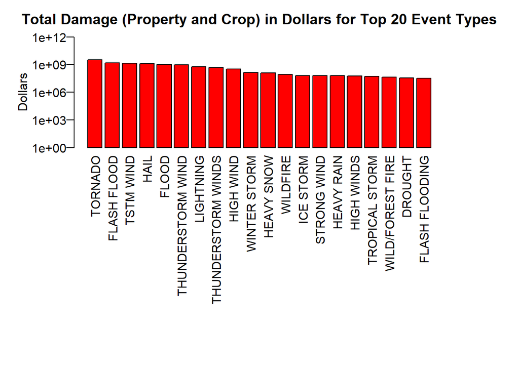

Figure 3.2: Top 20 weather event types with the most severe economic consequences.

```r
# use the top 20 data for plotting
top_eco_data <- eco_data_sorted[1:20, ]
par(mai=c(3,1,0.5,1), mgp=c(3,0.5,0), xpd=TRUE)
barplot(top_eco_data$DMG, names.arg=top_eco_data$EVTYPE,
main="Total Damage (Property and Crop) in Dollars for Top 20 Event Types", col="red", ylab="Dollars", ylim=c(1,1E+12), log='y', las=2)
```

From Figure 3.2, we can see that tornado, flood, and wind are the three diaster types that cause the most property and crop damage.

# 4 Conclusion

We analyzed the U.S. National Oceanic and Atmospheric Administration’s (NOAA) storm data from 1950 to 2011. We found from our analyses that tornado, heat, and flood are the top three disaster types incurring the most damage to people, based on the fatality and injury data. In comparison, tornado, flood, and wind are the top three disaster types causing the most property and crop damage. Accurate forecast and emergency preparedness for these types of adverse weather events are of paramount importance in saving people’s lives and minimizing economical loss.

# 5 Limitations of the Work

As can be seen from Figures 3.1 and 3.2, the event types in the NOAA data set are not mutually exclusive. For example, in Figure 3.2, we see “TSTM WIND”, “THUNDERSTORM WIND” and “THUNDERSTORM WINDS” all appearing among the top 20 event types causing the most damage. According to the NOAA data documentation file (Link: https://d396qusza40orc.cloudfront.net/repdata%2Fpeer2_doc%2Fpd01016005curr.pdf), these event types should all refer to the same adverse weather type, i.e., “thunderstorm wind”. Combining the damage amount caused by these three event types will likely change the ranking of which event type is the most damaging.

Because the goal of this project is to promote reproducible research, if any data cleaning is done to combine the multiple ways one specific event type is called, such cleaning should be thoroughly documented, so that other readers can reproduce the work.

For simplicity, this report does not include such data cleaning. As a result, the ranking of the most damaging event types will likely not be accurate. Therefore, the results shown in this report should NOT be used in funding decisions for emergency preparedness and planning of adverse weather events.

Thorough data cleaning is needed as future work so that more conclusive and accurate ranking results can be obtained to guide government funding and emergency planning activities.